STV2022 – Store tekstdata

[05] Bruke API (Stortinget)

[figure not shown]

Martin Søyland <martin.soyland@stv.uio.no>

# Disposisjon

1. Stortingets API oversikt 📜
2. .xml-formatet 🤷
3. stortingscrape 🐻
4. Oppgavene 🙈

# Stortingets API – oversikt

[data.stortinget.no](https://data.stortinget.no/dokumentasjon-og-hjelp/)

## Kobling mellom deler av API (eksempel)

```
Parlamentariske perioder
├── "2001-2005", "2017-2021", osv
└── https://data.stortinget.no/eksport/stortingsperioder
    └── Representanter i en periode
        └── "GHB", "SIVJ", "EIGE", "ALYS", osv
            ├── Representantdata
            │   └── https://data.stortinget.no/eksport/person?personid=GHB
            ├── Biografisk representantdata
            │   └── https://data.stortinget.no/eksport/kodetbiografi?personid=EIGE
            └── Bilde av representant
                └── https://data.stortinget.no/eksport/personbilde?personid=ALYS
```

## .xml-formatet

- APIer gir somregel enten `.xml` eller `.json`
- Vi bruker `.xml` i dag
  - det gjør også `stortingscrape`
- `.xml` det ligner på `.html`
- Kan leses med `rvest::read_html()`
  - går bakvei via pakken `xml2`
- (Hvis du treffer på `.json` -> `jsonlite`) 🤠

## Rå `.xml`

```
## <?xml version="1.0" encoding="utf8"?>
## <sesjoner_oversikt xmlns:i="http://www.w3.org/2001/XMLSchema-instance" xmlns="http://data.stortinget.no">
##   <respons_dato_tid>2022-09-15T11:22:49.3940964+02:00</respons_dato_tid>
##   <versjon>1.6</versjon>
##   <innevaerende_sesjon>
##     <respons_dato_tid>2022-09-15T11:22:49.378468+02:00</respons_dato_tid>
##     <versjon>1.6</versjon>
##     <fra>2021-10-01T00:00:00+02:00</fra>
##     <id>2021-2022</id>
##     <til>2022-09-30T23:59:00</til>
##   </innevaerende_sesjon>
##   <sesjoner_liste>
##     <sesjon>
##       <respons_dato_tid>2022-09-15T11:22:49.3940964+02:00</respons_dato_tid>
##       <versjon>1.6</versjon>
##       <fra>2024-10-01T00:00:00+02:00</fra>
##       <id>2024-2025</id>
##       <til>2025-09-30T23:59:00</til>
##     </sesjon>
##     <sesjon>
##       <respons_dato_tid>2022-09-15T11:22:49.3940964+02:00</respons_dato_tid>
##       <versjon>1.6</versjon>
##       <fra>2023-10-01T00:00:00+02:00</fra>
##       <id>2023-2024</id>
##       <til>2024-09-30T23:59:00</til>
##     </sesjon>
##     <sesjon>
##       <respons_dato_tid>2022-09-15T11:22:49.3940964+02:00</respons_dato_tid>
##       <versjon>1.6</versjon>
##       <fra>2022-10-01T00:00:00+02:00</fra>
##       <id>2022-2023</id>
##       <til>2023-09-30T23:59:00</til>
##     </sesjon>
##     <sesjon>
##       <respons_dato_tid>2022-09-15T11:22:49.3940964+02:00</respons_dato_tid>
##       <versjon>1.6</versjon>
##       <fra>2021-10-01T00:00:00+02:00</fra>
##       <id>2021-2022</id>
##       <til>2022-09-30T23:59:00</til>
##     </sesjon>
```

[output cut: 232 more lines]

```
##       <respons_dato_tid>2022-09-15T11:22:49.3940964+02:00</respons_dato_tid>
##       <versjon>1.6</versjon>
##       <fra>1987-10-01T01:00:00+02:00</fra>
##       <id>1987-88</id>
##       <til>1988-09-30T23:59:00</til>
##     </sesjon>
##     <sesjon>
##       <respons_dato_tid>2022-09-15T11:22:49.3940964+02:00</respons_dato_tid>
##       <versjon>1.6</versjon>
##       <fra>1986-10-01T01:00:00+02:00</fra>
##       <id>1986-87</id>
##       <til>1987-09-30T23:59:00</til>
##     </sesjon>
##   </sesjoner_liste>
## </sesjoner_oversikt>
```

## Strukturere `.xml`

```r
# Leser rå xml-fil
## sesjoner <- read_html("https://data.stortinget.no/eksport/sesjoner")

sesjoner
```

```
## {html_document}
## <html>
## [1] <body><sesjoner_oversikt xmlns:i="http://www.w3.org/2001/XMLSchema-instan ...
```

```r
# Trekker ut alle "id"-nodene
sesjoner %>% html_elements("id") %>% head()
```

```
## {xml_nodeset (6)}
## [1] <id>2021-2022</id>
## [2] <id>2024-2025</id>
## [3] <id>2023-2024</id>
## [4] <id>2022-2023</id>
## [5] <id>2021-2022</id>
## [6] <id>2020-2021</id>
```

```r
# Trekker ut sesjonstart
sesjoner %>%
  html_elements("sesjoner_liste > sesjon > fra") %>%
  html_text() %>%
  as.Date() %>%
  head()
```

```
## [1] "2024-10-01" "2023-10-01" "2022-10-01" "2021-10-01" "2020-10-01"
## [6] "2019-10-01"
```

```r
# Trekker ut sesjonslutt
sesjoner %>%
  html_elements("sesjoner_liste > sesjon > til") %>%
  html_text() %>%
  as.Date() %>%
  head()
```

```
## [1] "2025-09-30" "2024-09-30" "2023-09-30" "2022-09-30" "2021-09-30"
## [6] "2020-09-30"
```

```r
sesjoner_df <- tibble(
  from = sesjoner %>%
    html_elements("sesjoner_liste > sesjon > fra") %>%
    html_text() %>%
    as.Date(),
  id = sesjoner %>%
    html_elements("sesjoner_liste > sesjon > id") %>%
    html_text(),
  to = sesjoner %>%
    html_elements("sesjoner_liste > sesjon > til") %>%
    html_text() %>%
    as.Date()
)

sesjoner_df %>%
  filter(from < as.Date("2022-01-01")) %>%
  head()
```

```
## # A tibble: 6 × 3
##   from       id        to
##   <date>     <chr>     <date>
## 1 2021-10-01 2021-2022 2022-09-30
## 2 2020-10-01 2020-2021 2021-09-30
## 3 2019-10-01 2019-2020 2020-09-30
## 4 2018-10-01 2018-2019 2019-09-30
## 5 2017-10-01 2017-2018 2018-09-30
## 6 2016-10-01 2016-2017 2017-09-30
```

## Filosofi

- Brukervalg
  - Sy datasett etter eget behov
- Forenkle datastrukturer
  - 2 dimensionale datasett, når mulig
  - Lister med datasett, hvis nødvendig
- Enkel arbeidsflyt
  - Kobling av forskjellige deler av APIet
  - Example: MP age and roll call votes
- Begrense duplikater i data
  - Ungå at samme data hentes av flere funksjoner

## Omfang

[figure not shown]

## Omfang

```
## Stortingsperioder
## Sesjoner
## Fylker
## Emner
## Partier
## Alle partier
## Komiteer
## Alle komiteer
## Delegasjoner
## Person
## Personbilde
## Kodet personbiografi
## Representanter
## Dagens representanter
## Presidentskapet
## Regjering
## Spørsmål
## Enkeltspørsmål
## Saksganger
## Saker
## Ventede saker
## Sak
## Voteringer
## Voteringsforslag
## Voteringsvedtak
## Voteringsresultat
## Vedtak
## Møter
## Dagsorden
## Spørretimen
## Høringer
## Skriftlige innspill til høringer
## Høringsprogram
## Høringsinnspill
## Talerliste
## Publikasjoner
## Publikasjon
## Publikasjonsfigur
```

[Liste over alle funksjoner](https://martigso.github.io/stortingscrape/functions.html)

## Kobling mellom deler av API

```
`get_parlperiods()`
└── # datasett med alle stortingsperioder>
    └── `get_parlperiod_mps("2005-2009")`
        └── # datasett med alle representanter for periode
            ├── `get_mp("SIVJ")`
            │   └── # generell data om spesifikk representant
            ├── `get_mp_bio("SIVJ")`
            │   └── # biografiske data for representant
            └── `get_mp_pic("SIVJ")`
                └── # bilde av representant
```

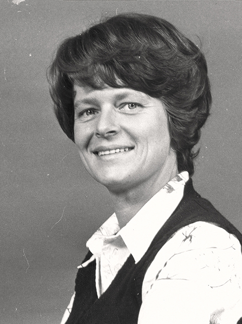

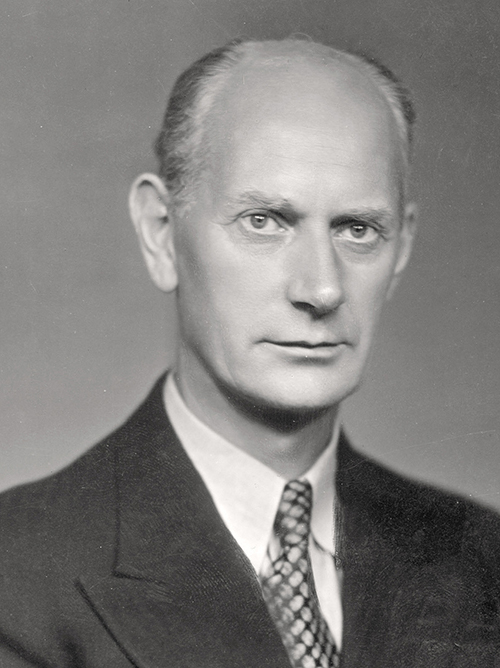

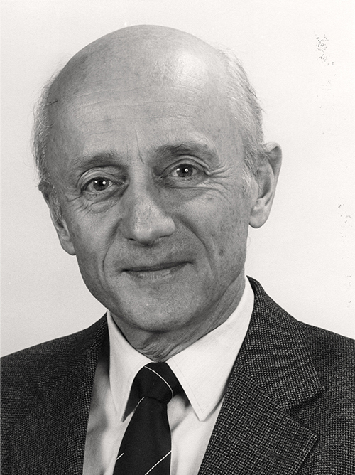

## Et faktisk eksempel på tekst til tall til analyse

> Hypotese: Representanter på Stortinget ble mer negative til regjeringens håndtering av koronapandemien over tid.

Fremgangsmåte: hente > strukturere > konvertere > analysere

Antagelse:  
🚨Sentiment måler negativitet/positivitet til regjeringen🚨